# Churn on Telcom - Exploration

Rizqi Haryastuti

## Brief Description

Laman ini berisi **eksplorasi** mengenai “aktifitas churn” pelanggan sebuah perusahaan telekomunikasi. Studi kasus berikut diberikan pada mata kuliah STK692 (TA 19/20), program studi S2 Statistika Terapan, IPB. Data dan keterangan dapat diakses melalui https://www.stat.ipb.ac.id/pasca/id/index.php/2019/11/19/527/.

Oleh: Muthia Nadhira Faladiba, Citra Komang Sari, Rizqi Haryastuti

```r
library(reshape2)
library(ggplot2)
library(gridExtra)
library(dplyr)
library(factoextra)
library(NbClust)
library(ggpubr)
library(viridis)
library(randomForest)
library(caret)
library(Information)
```

**Input data**

```r
loc <- "D:/RH/2 AKADEMIK S2/Semester 3/STK692 - Studi Kasus/telco.csv"
data <- read.csv(loc, header=T, sep=";")

sum(is.na(data))
```

```
## [1] 0
```

```r
str(data)
```

```
## 'data.frame':    90000 obs. of  18 variables:
##  $ MSISDN           : int  1 2 3 4 5 6 7 8 9 10 ...
##  $ los              : int  1175 17044 185 943 2319 975 199 1393 209 209 ...
##  $ rchg_rev         : int  30000 10000 25000 50000 30000 0 30000 20000 0 0 ...
##  $ rchg_trx         : int  3 1 1 1 4 0 5 2 0 0 ...
##  $ voice_rev        : Factor w/ 26364 levels "0","100","1000",..: 1819 24017 17639 7043 18583 11301 25478 1 9464 21727 ...
##  $ voice_trx        : int  114 11 3 72 13 9 24 46 1 26 ...
##  $ voice_mou        : int  121 3 151 149 104 15 163 386 0 217 ...
##  $ voice_dou        : int  6 4 3 7 5 3 6 4 1 4 ...
##  $ sms_rev          : int  1480 620 3520 5245 5495 3010 3450 1150 4370 4180 ...
##  $ sms_trx          : int  21 3 18 32 28 16 18 5 19 23 ...
##  $ sms_dou          : int  7 1 4 7 5 5 6 3 6 4 ...
##  $ broadband_rev    : Factor w/ 6020 levels "0","1","10","10,5",..: 4216 4586 1 1 1 1 1 3007 1 1 ...
##  $ broadband_usg    : Factor w/ 25375 levels "0","0,000103951",..: 22044 832 10803 1 1 1 1 4364 1 1 ...
##  $ broadband_dou    : int  7 2 7 0 0 0 0 1 0 0 ...
##  $ voice_package_rev: int  7500 2500 8700 19550 12800 4100 43850 13300 7700 2500 ...
##  $ voice_package_trx: int  3 1 2 5 3 1 10 3 2 1 ...
##  $ voice_package_dou: int  2 1 2 5 2 1 7 3 2 1 ...
##  $ lapsed_flag      : int  0 1 0 0 0 1 0 0 0 0 ...
```

Pada peubah `voice_rev`, `broadband_rev`, dan `broadband_usg` terjadi kesalahan deteksi karakter. Seharusnya desimal menggunakan `.` namun terbaca `,`, sehingga diubah terlebih dahulu.

**Arrange data**

```r
voice_rev2 <- gsub(",",".",data$voice_rev)
data$voice_rev = as.numeric(voice_rev2)

broadband_rev2 <- gsub(",",".",data$broadband_rev)
data$broadband_rev = as.numeric(broadband_rev2)

broadband_usg2 <- gsub(",",".",data$broadband_usg)
data$broadband_usg = as.numeric(broadband_usg2)

data$lapsed_flag = as.factor(as.character(data$lapsed_flag))
```

```r
prop.table(table(data$lapsed_flag))
```

```
##
##      0      1
## 0.6822 0.3178
```

```r
summary(data)
```

```
##      MSISDN           los            rchg_rev          rchg_trx
##  Min.   :    1   Min.   :    19   Min.   :      0   Min.   : 0.000
##  1st Qu.:22501   1st Qu.:   400   1st Qu.:      0   1st Qu.: 0.000
##  Median :45001   Median :  1276   Median :  20000   Median : 1.000
##  Mean   :45001   Mean   :  3474   Mean   :  28553   Mean   : 1.804
##  3rd Qu.:67500   3rd Qu.:  2619   3rd Qu.:  40000   3rd Qu.: 3.000
##  Max.   :90000   Max.   :330788   Max.   :2210000   Max.   :38.000
##    voice_rev        voice_trx        voice_mou        voice_dou
##  Min.   :     0   Min.   :  0.00   Min.   :   0.0   Min.   :0.000
##  1st Qu.:   605   1st Qu.:  5.00   1st Qu.:   6.0   1st Qu.:2.000
##  Median :  3993   Median : 16.00   Median :  46.0   Median :4.000
##  Mean   :  8434   Mean   : 30.16   Mean   : 115.1   Mean   :4.071
##  3rd Qu.: 10452   3rd Qu.: 39.00   3rd Qu.: 138.0   3rd Qu.:6.000
##  Max.   :636783   Max.   :854.00   Max.   :4718.0   Max.   :7.000
##     sms_rev          sms_trx           sms_dou      broadband_rev
##  Min.   :     0   Min.   :   0.00   Min.   :0.000   Min.   :     0
##  1st Qu.:   440   1st Qu.:   3.00   1st Qu.:2.000   1st Qu.:     0
##  Median :  2100   Median :  13.00   Median :4.000   Median :     0
##  Mean   :  4580   Mean   :  34.84   Mean   :4.049   Mean   :  4244
##  3rd Qu.:  5775   3rd Qu.:  34.00   3rd Qu.:6.000   3rd Qu.:     0
##  Max.   :122450   Max.   :9281.00   Max.   :7.000   Max.   :646312
##  broadband_usg       broadband_dou   voice_package_rev voice_package_trx
##  Min.   :    0.000   Min.   :0.000   Min.   :     0    Min.   : 1.000
##  1st Qu.:    0.000   1st Qu.:0.000   1st Qu.:  4350    1st Qu.: 1.000
##  Median :    0.000   Median :0.000   Median :  8450    Median : 2.000
##  Mean   :  114.002   Mean   :1.249   Mean   : 12350    Mean   : 3.295
##  3rd Qu.:    0.018   3rd Qu.:1.000   3rd Qu.: 16850    3rd Qu.: 4.000
##  Max.   :21177.943   Max.   :7.000   Max.   :179450    Max.   :51.000
##  voice_package_dou lapsed_flag
##  Min.   :1.000     0:61398
##  1st Qu.:1.000     1:28602
##  Median :2.000
##  Mean   :2.704
##  3rd Qu.:4.000
##  Max.   :7.000
```

### Visual lapsed_flag (churn)

```r
table(data$lapsed_flag)
```

```
##
##     0     1
## 61398 28602
```

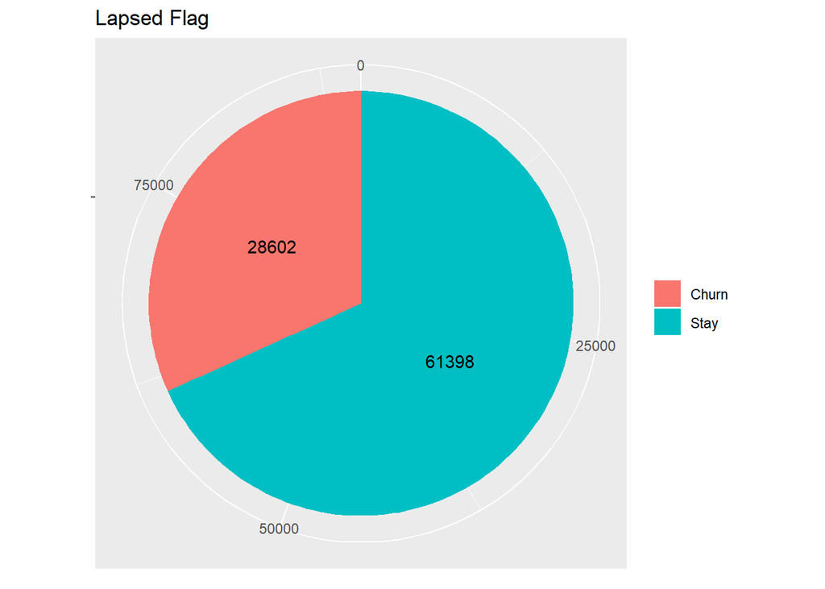

```r
cs <- data.frame(var=c("Stay","Churn"),val=c(61398,28602))
ggplot(cs, aes(x="", y=val, fill=var)) +
  geom_bar(stat="identity", width=1) +
  coord_polar("y", start=0) +
  geom_text(aes(label=paste0(val)), position=position_stack(vjust=0.5)) +
  labs(x=NULL, y=NULL, fill=NULL, title="Lapsed Flag")
```

### Visualisasi peubah prediktor

```r
class = ifelse(rep(data$lapsed_flag,times=16)==1,"Churn","Stay")

dfm <- data.frame(class,melt(data[-c(1,18)]))
```

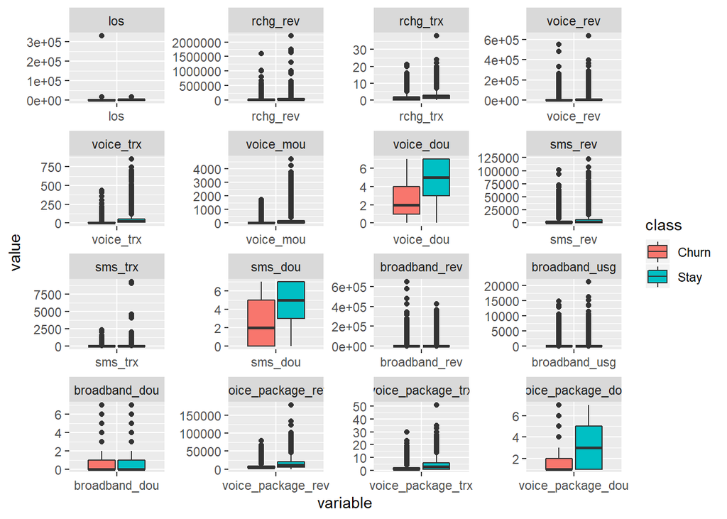

```r
ggplot(dfm, aes(x=variable, y=value)) +
  geom_boxplot(aes(fill=class)) +
  facet_wrap( ~ variable, scales="free")
```

Berikut adalah gambaran proporsi revenue yang ada dalam `data telco`.

### Visualisasi proporsi revenue (keseluruhan)

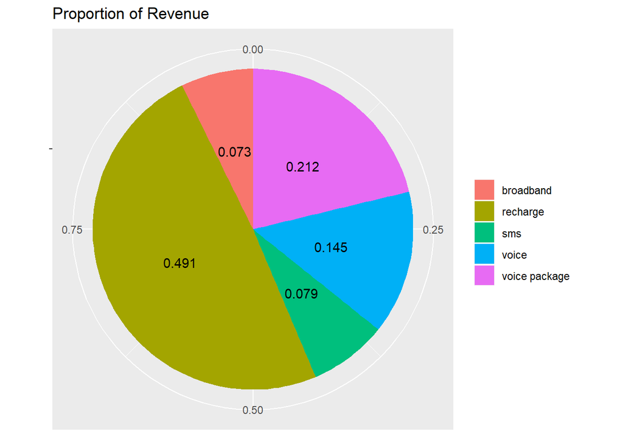

```r
#
sum.rchg <- sum(data$rchg_rev)
sum.voice <- sum(data$voice_rev)
sum.sms <- sum(data$sms_rev)
sum.broad <- sum(data$broadband_rev)
sum.voicepack <- sum(data$voice_package_rev)
sum.sum <- sum(sum.rchg+sum.voice+sum.sms+sum.broad+sum.voicepack)

#
revenue <- c("recharge","voice","sms","broadband","voice package")
proportion <- c(sum.rchg/sum.sum, sum.voice/sum.sum, sum.sms/sum.sum,
                sum.broad/sum.sum, sum.voicepack/sum.sum)
dfrev <- data.frame(revenue,proportion)

#
ggplot(dfrev, aes(x="", y=proportion, fill=revenue)) +
  geom_bar(stat="identity", width=1) +
  coord_polar("y", start=0) +
  geom_text(aes(label=paste0(round(proportion,3))), position=position_stack(vjust=0.5)) +
  labs(x=NULL, y=NULL, fill=NULL, title="Proportion of Revenue")
```

### Visualisasi proporsi revenue (berdasarkan class “Churn” & “Stay”)

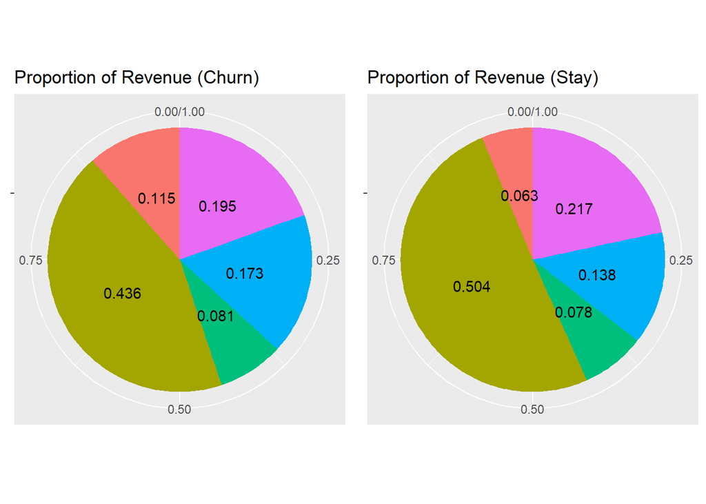

```r
## churn
sum.rchg1 <- sum(data[which(data$lapsed_flag=="1"),3])
sum.voice1 <- sum(data[which(data$lapsed_flag=="1"),5])
sum.sms1 <- sum(data[which(data$lapsed_flag=="1"),9])
sum.broad1 <- sum(data[which(data$lapsed_flag=="1"),12])
sum.voicepack1 <- sum(data[which(data$lapsed_flag=="1"),15])
sum.sum1 <- sum(sum.rchg1+sum.voice1+sum.sms1+sum.broad1+sum.voicepack1)

#
revenue <- c("recharge","voice","sms","broadband","voice package")
proportion1 <- c(sum.rchg1/sum.sum1, sum.voice1/sum.sum1, sum.sms1/sum.sum1,
                sum.broad1/sum.sum1, sum.voicepack1/sum.sum1)
dfrev1 <- data.frame(revenue,proportion1)

#
rev1 <- ggplot(dfrev1, aes(x="", y=proportion1, fill=revenue)) +
  geom_bar(stat="identity", width=1) +
  coord_polar("y", start=0) + theme(legend.position = "none") +
  geom_text(aes(label=paste0(round(proportion1,3))), position=position_stack(vjust=0.5)) +
  labs(x=NULL, y=NULL, fill=NULL, title="Proportion of Revenue (Churn)")

## stay
sum.rchg0 <- sum(data[which(data$lapsed_flag=="0"),3])
sum.voice0 <- sum(data[which(data$lapsed_flag=="0"),5])
sum.sms0 <- sum(data[which(data$lapsed_flag=="0"),9])
sum.broad0 <- sum(data[which(data$lapsed_flag=="0"),12])
sum.voicepack0 <- sum(data[which(data$lapsed_flag=="0"),15])
sum.sum0 <- sum(sum.rchg0+sum.voice0+sum.sms0+sum.broad0+sum.voicepack0)

#
revenue <- c("recharge","voice","sms","broadband","voice package")
proportion0 <- c(sum.rchg0/sum.sum0, sum.voice0/sum.sum0, sum.sms0/sum.sum0,
                 sum.broad0/sum.sum0, sum.voicepack0/sum.sum0)
dfrev0 <- data.frame(revenue,proportion0)

#
rev0 <- ggplot(dfrev0, aes(x="", y=proportion0, fill=revenue)) +
  geom_bar(stat="identity", width=1) +
  coord_polar("y", start=0) + theme(legend.position = "none") +
  geom_text(aes(label=paste0(round(proportion0,3))), position=position_stack(vjust=0.5)) +
  labs(x=NULL, y=NULL, fill=NULL, title="Proportion of Revenue (Stay)")

##
grid.arrange(rev1,rev0,ncol=2)
```

## Bagaimana dengan *length of stay*?

Tentunya kita beranggapan bahwa pelanggan yang Churn adalah pelanggan memiliki nilai length of stay atau los yang relatif lebih kecil atau sedikit dibanding pelanggan Stay.

Pada bagian `summary(data)` didapatkan adanya kejanggalan pada nilai `max(data$los)`, yakni sebesar **330788** hari atau sekitar **906** tahun. Hal tersebut menjadi tidak make sense dan perlu pertimbangan untuk melakukan analisis selanjutnya.

```r
IQR = 2619-400 #q3-q1 data all
minor.outlier <- (2619 + (1.5*IQR)) #5947.5 hari = 16.29 tahun
mayor.outlier <- (2619 + (3*IQR)) #9276 hari = 25.41 tahun

nrow(data[which(data$los>minor.outlier),]) #12789
data <- data[-which(data$los>minor.outlier),-c(1,24)] #77211
table(data$lapsed_flag)
summary(data)
```

## Eksplorasi tiap layanan

*RECHARGE*

```r
## apakah jika rchg_trx==0 maka rchg_rev==0?
nrow(data[which(data$rchg_rev==0 & data$rchg_trx!=0),])
nrow(data[which(data$rchg_rev!=0 & data$rchg_trx==0),])
nrow(data[which(data$rchg_rev==0 & data$rchg_trx==0),])
nrow(data)-nrow(data[which(data$rchg_rev==0 & data$rchg_trx==0),])
## pelanggan rchg_trx==0 dan rchg_rev==0 belum tentu yang lain 0
```

*VOICE*

```r
nrow(data[which(data$voice_rev==0 & data$voice_trx!=0),]) #6333
nrow(data[which(data$voice_rev!=0 & data$voice_trx==0),]) #0
nrow(data[which(data$voice_rev==0 & data$voice_trx==0),]) #9814

nrow(data[which(data$voice_rev==0 & data$voice_trx==0 & data$voice_mou==0),]) #9814 (mou!=0 #0)
nrow(data[which(data$voice_rev==0 & data$voice_trx==0 & data$voice_mou==0 & data$voice_dou==0),]) #9814 (dou!=0 #0)

nrow(data[which(data$voice_rev==0 & data$voice_trx!=0 & data$voice_mou!=0),]) #6195
nrow(data[which(data$voice_rev==0 & data$voice_trx!=0 & data$voice_mou==0),]) #138

nrow(data[which(data$voice_rev==0 & data$voice_trx!=0 &  data$voice_mou!=0 & data$voice_dou!=0),]) #6195
nrow(data[which(data$voice_rev==0 & data$voice_trx!=0 &  data$voice_mou!=0 & data$voice_dou==0),]) #0

nrow(data[which(data$voice_rev==0 & data$voice_trx!=0 &  data$voice_mou==0 & data$voice_dou!=0),]) #138
nrow(data[which(data$voice_rev==0 & data$voice_trx!=0 &  data$voice_mou==0 & data$voice_dou==0),]) #0

nrow(data[which(data$voice_mou==0 & data$voice_dou!=0),]) #4330
nrow(data[which(data$voice_mou!=0 & data$voice_dou==0),]) #0
nrow(data[which(data$voice_mou!=0 & data$voice_dou!=0),]) #75856

nrow(data[which(data$voice_rev!=0 & data$voice_trx!=0),]) #73853

nrow(data[which(data$voice_rev!=0 & data$voice_trx!=0 &  data$voice_mou!=0 & data$voice_dou!=0),]) #69661
nrow(data[which(data$voice_rev!=0 & data$voice_trx!=0 &  data$voice_mou==0 & data$voice_dou!=0),]) #4192
```

*SMS*

```r
nrow(data[which(data$sms_rev==0 & data$sms_trx==0),]) #12302
nrow(data[which(data$sms_rev==0 & data$sms_trx!=0),]) #2849
nrow(data[which(data$sms_rev!=0 & data$sms_trx==0),]) #0
nrow(data[which(data$sms_rev!=0 & data$sms_trx!=0),]) #74849

nrow(data[which(data$sms_rev==0 & data$sms_trx==0 & data$sms_dou==0),]) #12302
nrow(data[which(data$sms_rev==0 & data$sms_trx==0 & data$sms_dou!=0),]) #0

nrow(data[which(data$sms_rev==0 & data$sms_trx!=0 & data$sms_dou==0),]) #0
nrow(data[which(data$sms_rev==0 & data$sms_trx!=0 & data$sms_dou!=0),]) #2849

nrow(data[which(data$sms_rev!=0 & data$sms_trx!=0 & data$sms_dou==0),]) #
nrow(data[which(data$sms_rev!=0 & data$sms_trx!=0 & data$sms_dou!=0),]) #74849
```

*BROADBAND*

```r
nrow(data[which(data$broadband_rev==0 & data$broadband_usg==0),]) #63075
nrow(data[which(data$broadband_rev==0 & data$broadband_usg!=0),]) #7660
nrow(data[which(data$broadband_rev!=0 & data$broadband_usg==0),]) #662
nrow(data[which(data$broadband_rev!=0 & data$broadband_usg!=0),]) #18603

nrow(data[which(data$broadband_rev==0 & data$broadband_usg==0 & data$broadband_dou==0),]) #63068
nrow(data[which(data$broadband_rev==0 & data$broadband_usg==0 & data$broadband_dou!=0),]) #7

nrow(data[which(data$broadband_rev!=0 & data$broadband_usg==0 &
                  data$broadband_dou==0),]) #0
nrow(data[which(data$broadband_rev!=0 & data$broadband_usg==0 &
                  data$broadband_dou!=0),]) #662

nrow(data[which(data$broadband_rev==0 & data$broadband_usg!=0 & data$broadband_dou==0),]) #0
nrow(data[which(data$broadband_rev==0 & data$broadband_usg!=0 & data$broadband_dou!=0),]) #7660

nrow(data[which(data$broadband_rev!=0 & data$broadband_usg!=0 & data$broadband_dou==0),]) #0
nrow(data[which(data$broadband_rev!=0 & data$broadband_usg!=0 & data$broadband_dou!=0),]) #18603
```

*VOICE PACKAGE*

```r
nrow(data[which(data$voice_package_rev==0 & data$voice_package_trx==0),]) #0
nrow(data[which(data$voice_package_rev==0 & data$voice_package_trx!=0),]) #577
nrow(data[which(data$voice_package_rev!=0 & data$voice_package_trx==0),]) #0
nrow(data[which(data$voice_package_rev!=0 & data$voice_package_trx!=0),]) #89423

nrow(data[which(data$voice_package_rev==0 & data$voice_package_trx!=0 & data$voice_package_dou==0),]) #0
nrow(data[which(data$voice_package_rev==0 & data$voice_package_trx!=0 & data$voice_package_dou!=0),]) #577

nrow(data[which(data$voice_package_rev!=0 & data$voice_package_trx!=0 & data$voice_package_dou==0),]) #0
nrow(data[which(data$voice_package_rev!=0 & data$voice_package_trx!=0 & data$voice_package_dou!=0),]) #89423
```

Setelah menelusuri elemen-elemen yang ada pada setiap layanan, didapatkan pola-pola yang unik dari pelanggan. Sehingga selanjutnya dibuat kategori-kategori yang dapat mewakili pola pelanggan tersebut.

**Membuat peubah kategori untuk tiap layanan**

*RECHARGE*

```r
class.rchg <- as.factor(ifelse(data[,3]==0 & data[,4]==0,"0","1"))
```

*VOICE*

```r
class.voice <- as.factor(ifelse(data[,5]==0 & data[,6]==0 & data[,7]==0 & data[,8]==0,"0",
                                ifelse(data[,5]==0 & data[,6]!=0 & data[,7]!=0 & data[,8]!=0,"1",
                                       ifelse(data[,5]==0 & data[,6]!=0 & data[,7]==0 & data[,8]!=0,"2",
                                              ifelse(data[,5]!=0 & data[,6]!=0 & data[,7]==0 & data[,8]!=0,"3",
                                                     "4")))))
```

*BROADBAND*

```r
class.broad <- as.factor(ifelse(data[,12]==0 & data[,14]==0 & data[,13]==0,"0",
                              ifelse(data[,12]==0 & data[,14]!=0 & data[,13]!=0,"2",
                                     ifelse(data[,12]!=0 & data[,14]!=0 & data[,13]!=0,"3",
                                            "1"))))
```

*SMS*

```r
class.sms <- as.factor(ifelse(data[,9]==0 & data[,10]==0 & data[,11]==0,"0",
                              ifelse(data[,9]!=0 & data[,10]!=0 & data[,11]!=0,"2",
                                     "1")))
```

*VOICE PACKAGE*

```r
class.voice_pack <- as.factor(ifelse(data[,15]!=0 & data[,16]!=0 & data[,17]!=0,"1",
                                     "0"))
```

### Visualisasi peubah kategorik tiap layanan

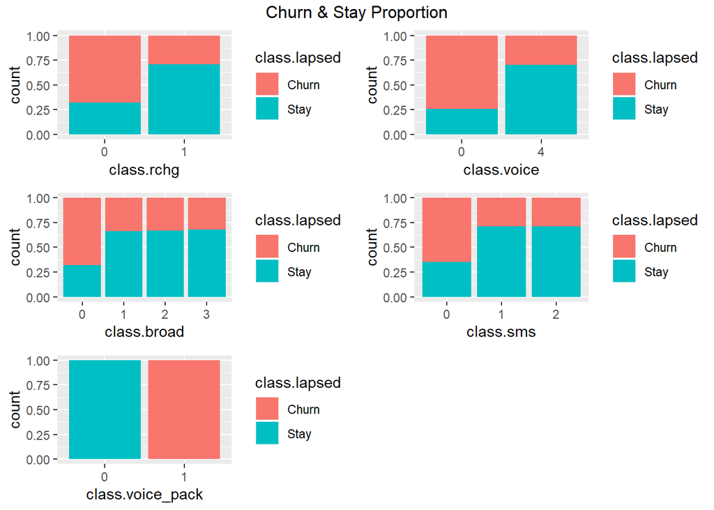

```r
class.lapsed = ifelse(data$lapsed_flag==1,"Churn","Stay")
dfclass = data.frame(class.lapsed,class.rchg,class.voice,class.broad,class.sms,class.voice_pack)

p.rchg <- ggplot(dfclass, aes(x=class.rchg, fill=class.lapsed)) +
  geom_bar(position="fill")

p.voice <- ggplot(dfclass, aes(x=class.voice, fill=class.lapsed)) +
  geom_bar(position="fill")

p.broad <- ggplot(dfclass, aes(x=class.broad, fill=class.lapsed)) +
  geom_bar(position="fill")

p.sms <- ggplot(dfclass, aes(x=class.sms, fill=class.lapsed)) +
  geom_bar(position="fill")

p.voice_pack <- ggplot(dfclass, aes(x=class.voice_pack, fill=class.lapsed)) +
  geom_bar(position="fill")

grid.arrange(p.rchg,p.voice,p.broad,p.sms,p.voice_pack,top="Churn & Stay Proportion")
```

```r
## risiko rchg
prop.table(table(dfclass$class.lapsed,dfclass$class.rchg),margin=2)
```

```
##
##                 0         1
##   Churn 0.6801225 0.2893467
##   Stay  0.3198775 0.7106533
```

```r
## risiko voice
prop.table(table(dfclass$class.lapsed,dfclass$class.voice),margin=2)
```

```
##
##                 0         4
##   Churn 0.7446196 0.2956113
##   Stay  0.2553804 0.7043887
```

```r
## risiko broadband
prop.table(table(dfclass$class.lapsed,dfclass$class.broad),margin=2)
```

```
##
##                 0         1         2         3
##   Churn 0.6829971 0.3373357 0.3293718 0.3208643
##   Stay  0.3170029 0.6626643 0.6706282 0.6791357
```

```r
## risiko SMS
prop.table(table(dfclass$class.lapsed,dfclass$class.sms),margin=2)
```

```
##
##                 0         1         2
##   Churn 0.6479545 0.2874379 0.2901780
##   Stay  0.3520455 0.7125621 0.7098220
```

```r
## risiko voice_package
prop.table(table(dfclass$class.lapsed,dfclass$class.voice_pack),margin=2)
```

```
##
##         0 1
##   Churn 0 1
##   Stay  1 0
```

Untuk memperkuat gambaran tersebut, dilakukan pemodelan regresi logistik yang melibatkan 5 peubah kategorik baru tersebut sebagai prediktor serta lapsed_flag sebagai respon.

```r
m1 <- glm(class.lapsed~., data=dfclass, family=binomial(link="logit"))
summary(m1)
```

```
##
## Call:
## glm(formula = class.lapsed ~ ., family = binomial(link = "logit"),
##     data = dfclass)
##
## Deviance Residuals:
##        Min          1Q      Median          3Q         Max
## -2.409e-06  -2.409e-06   2.409e-06   2.409e-06   2.409e-06
##
## Coefficients:
##                     Estimate Std. Error z value Pr(>|z|)
## (Intercept)        2.657e+01  1.976e+04   0.001    0.999
## class.rchg1        6.841e-07  6.228e+03   0.000    1.000
## class.voice4      -1.437e-06  8.084e+03   0.000    1.000
## class.broad1       1.757e-07  1.920e+04   0.000    1.000
## class.broad2      -3.396e-06  2.453e+04   0.000    1.000
## class.broad3      -1.509e-06  1.955e+04   0.000    1.000
## class.sms1         1.030e-06  5.369e+03   0.000    1.000
## class.sms2         2.713e-06  7.369e+03   0.000    1.000
## class.voice_pack1 -5.313e+01  2.851e+03  -0.019    0.985
##
## (Dispersion parameter for binomial family taken to be 1)
##
##     Null deviance: 9.8361e+04  on 77210  degrees of freedom
## Residual deviance: 4.4795e-07  on 77202  degrees of freedom
## AIC: 18
##
## Number of Fisher Scoring iterations: 25
```

Namun dari output tersebut kami menemukan kejanggalan. Output regresi logistik pada R Markdown tidak sama dengan output ketika kami menjalankan program pada RStudio atau R CLI. Berikut kami sertakan output dari RStudio:

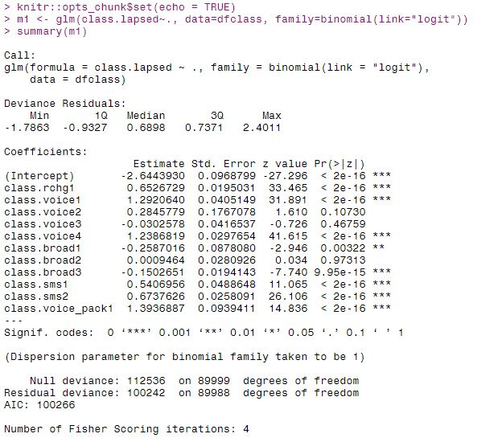

Output Regresi Logistik

Setiap layanan terdapat minimal satu kategori yang signifikan pada taraf nyata 5%, maka cukup bukti untuk menyatakan bahwa pengelompokkan setiap layanan signfikan.